# Risk Factor Analysis

## Outcome Variable

**Outcome Variable:** wasted

## Predictor Variables

**Intervention Variable:** mage

**Adjustment Set:**

- arm
- meducyrs
- feducyrs
- W_mhtcm
- W_mwtkg
- W_mbmi
- single
- delta_meducyrs
- delta_feducyrs
- delta_W_mhtcm
- delta_W_mwtkg
- delta_W_mbmi
- delta_single

## Stratifying Variables

The analysis was stratified on these variable(s):

- agecat
- studyid
- country

## Data Summary

| agecat | studyid | country | mage | wasted | n_cell | n |
| --- | --- | --- | --- | --- | --- | --- |
| Birth | ki0047075b-MAL-ED | BANGLADESH | [20-30) | 0 | 128 | 215 |
| Birth | ki0047075b-MAL-ED | BANGLADESH | [20-30) | 1 | 20 | 215 |
| Birth | ki0047075b-MAL-ED | BANGLADESH | <20 | 0 | 20 | 215 |
| Birth | ki0047075b-MAL-ED | BANGLADESH | <20 | 1 | 8 | 215 |
| Birth | ki0047075b-MAL-ED | BANGLADESH | >=30 | 0 | 31 | 215 |
| Birth | ki0047075b-MAL-ED | BANGLADESH | >=30 | 1 | 8 | 215 |
| Birth | ki0047075b-MAL-ED | BRAZIL | [20-30) | 0 | 37 | 62 |
| Birth | ki0047075b-MAL-ED | BRAZIL | [20-30) | 1 | 2 | 62 |
| Birth | ki0047075b-MAL-ED | BRAZIL | <20 | 0 | 8 | 62 |
| Birth | ki0047075b-MAL-ED | BRAZIL | <20 | 1 | 0 | 62 |
| Birth | ki0047075b-MAL-ED | BRAZIL | >=30 | 0 | 15 | 62 |
| Birth | ki0047075b-MAL-ED | BRAZIL | >=30 | 1 | 0 | 62 |
| Birth | ki0047075b-MAL-ED | INDIA | [20-30) | 0 | 32 | 45 |
| Birth | ki0047075b-MAL-ED | INDIA | [20-30) | 1 | 4 | 45 |
| Birth | ki0047075b-MAL-ED | INDIA | <20 | 0 | 7 | 45 |
| Birth | ki0047075b-MAL-ED | INDIA | <20 | 1 | 0 | 45 |
| Birth | ki0047075b-MAL-ED | INDIA | >=30 | 0 | 1 | 45 |
| Birth | ki0047075b-MAL-ED | INDIA | >=30 | 1 | 1 | 45 |
| Birth | ki0047075b-MAL-ED | NEPAL | [20-30) | 0 | 20 | 26 |
| Birth | ki0047075b-MAL-ED | NEPAL | [20-30) | 1 | 1 | 26 |
| Birth | ki0047075b-MAL-ED | NEPAL | <20 | 0 | 0 | 26 |
| Birth | ki0047075b-MAL-ED | NEPAL | <20 | 1 | 0 | 26 |
| Birth | ki0047075b-MAL-ED | NEPAL | >=30 | 0 | 4 | 26 |
| Birth | ki0047075b-MAL-ED | NEPAL | >=30 | 1 | 1 | 26 |
| Birth | ki0047075b-MAL-ED | PERU | [20-30) | 0 | 110 | 228 |
| Birth | ki0047075b-MAL-ED | PERU | [20-30) | 1 | 3 | 228 |
| Birth | ki0047075b-MAL-ED | PERU | <20 | 0 | 61 | 228 |
| Birth | ki0047075b-MAL-ED | PERU | <20 | 1 | 2 | 228 |
| Birth | ki0047075b-MAL-ED | PERU | >=30 | 0 | 52 | 228 |
| Birth | ki0047075b-MAL-ED | PERU | >=30 | 1 | 0 | 228 |

[output cut: 396 more lines]

The following strata were considered:

- agecat: 24 months, studyid: ki0047075b-MAL-ED, country: BANGLADESH
- agecat: 24 months, studyid: ki0047075b-MAL-ED, country: BRAZIL
- agecat: 24 months, studyid: ki0047075b-MAL-ED, country: INDIA
- agecat: 24 months, studyid: ki0047075b-MAL-ED, country: NEPAL
- agecat: 24 months, studyid: ki0047075b-MAL-ED, country: PERU
- agecat: 24 months, studyid: ki0047075b-MAL-ED, country: SOUTH AFRICA
- agecat: 24 months, studyid: ki0047075b-MAL-ED, country: TANZANIA, UNITED REPUBLIC OF
- agecat: 24 months, studyid: ki1000108-CMC-V-BCS-2002, country: INDIA
- agecat: 24 months, studyid: ki1000108-IRC, country: INDIA
- agecat: 24 months, studyid: ki1000109-EE, country: PAKISTAN
- agecat: 24 months, studyid: ki1017093-NIH-Birth, country: BANGLADESH
- agecat: 24 months, studyid: ki1017093b-PROVIDE, country: BANGLADESH
- agecat: 24 months, studyid: ki1017093c-NIH-Crypto, country: BANGLADESH
- agecat: 24 months, studyid: ki1066203-TanzaniaChild2, country: TANZANIA, UNITED REPUBLIC OF
- agecat: 24 months, studyid: ki1101329-Keneba, country: GAMBIA
- agecat: 24 months, studyid: ki1113344-GMS-Nepal, country: NEPAL
- agecat: 24 months, studyid: ki1119695-PROBIT, country: BELARUS
- agecat: 24 months, studyid: ki1126311-ZVITAMBO, country: ZIMBABWE
- agecat: 24 months, studyid: ki1135781-COHORTS, country: GUATEMALA
- agecat: 24 months, studyid: ki1135781-COHORTS, country: INDIA
- agecat: 24 months, studyid: ki1135781-COHORTS, country: PHILIPPINES
- agecat: 24 months, studyid: ki1148112-LCNI-5, country: MALAWI
- agecat: 24 months, studyid: kiGH5241-JiVitA-3, country: BANGLADESH
- agecat: 6 months, studyid: ki0047075b-MAL-ED, country: BANGLADESH
- agecat: 6 months, studyid: ki0047075b-MAL-ED, country: BRAZIL
- agecat: 6 months, studyid: ki0047075b-MAL-ED, country: INDIA
- agecat: 6 months, studyid: ki0047075b-MAL-ED, country: NEPAL
- agecat: 6 months, studyid: ki0047075b-MAL-ED, country: PERU
- agecat: 6 months, studyid: ki0047075b-MAL-ED, country: SOUTH AFRICA
- agecat: 6 months, studyid: ki0047075b-MAL-ED, country: TANZANIA, UNITED REPUBLIC OF
- agecat: 6 months, studyid: ki1000108-CMC-V-BCS-2002, country: INDIA
- agecat: 6 months, studyid: ki1000108-IRC, country: INDIA
- agecat: 6 months, studyid: ki1000109-EE, country: PAKISTAN
- agecat: 6 months, studyid: ki1000304b-SAS-CompFeed, country: INDIA
- agecat: 6 months, studyid: ki1000304b-SAS-FoodSuppl, country: INDIA
- agecat: 6 months, studyid: ki1017093-NIH-Birth, country: BANGLADESH
- agecat: 6 months, studyid: ki1017093b-PROVIDE, country: BANGLADESH
- agecat: 6 months, studyid: ki1017093c-NIH-Crypto, country: BANGLADESH
- agecat: 6 months, studyid: ki1066203-TanzaniaChild2, country: TANZANIA, UNITED REPUBLIC OF
- agecat: 6 months, studyid: ki1101329-Keneba, country: GAMBIA
- agecat: 6 months, studyid: ki1112895-Guatemala BSC, country: GUATEMALA
- agecat: 6 months, studyid: ki1113344-GMS-Nepal, country: NEPAL
- agecat: 6 months, studyid: ki1119695-PROBIT, country: BELARUS
- agecat: 6 months, studyid: ki1126311-ZVITAMBO, country: ZIMBABWE
- agecat: 6 months, studyid: ki1135781-COHORTS, country: GUATEMALA
- agecat: 6 months, studyid: ki1135781-COHORTS, country: INDIA
- agecat: 6 months, studyid: ki1135781-COHORTS, country: PHILIPPINES
- agecat: 6 months, studyid: ki1148112-LCNI-5, country: MALAWI
- agecat: 6 months, studyid: kiGH5241-JiVitA-3, country: BANGLADESH
- agecat: Birth, studyid: ki0047075b-MAL-ED, country: BANGLADESH
- agecat: Birth, studyid: ki0047075b-MAL-ED, country: BRAZIL
- agecat: Birth, studyid: ki0047075b-MAL-ED, country: INDIA
- agecat: Birth, studyid: ki0047075b-MAL-ED, country: NEPAL
- agecat: Birth, studyid: ki0047075b-MAL-ED, country: PERU
- agecat: Birth, studyid: ki0047075b-MAL-ED, country: SOUTH AFRICA
- agecat: Birth, studyid: ki0047075b-MAL-ED, country: TANZANIA, UNITED REPUBLIC OF
- agecat: Birth, studyid: ki1000108-CMC-V-BCS-2002, country: INDIA
- agecat: Birth, studyid: ki1000108-IRC, country: INDIA
- agecat: Birth, studyid: ki1000109-EE, country: PAKISTAN
- agecat: Birth, studyid: ki1000304b-SAS-CompFeed, country: INDIA
- agecat: Birth, studyid: ki1017093-NIH-Birth, country: BANGLADESH
- agecat: Birth, studyid: ki1017093b-PROVIDE, country: BANGLADESH
- agecat: Birth, studyid: ki1017093c-NIH-Crypto, country: BANGLADESH
- agecat: Birth, studyid: ki1101329-Keneba, country: GAMBIA
- agecat: Birth, studyid: ki1113344-GMS-Nepal, country: NEPAL
- agecat: Birth, studyid: ki1119695-PROBIT, country: BELARUS
- agecat: Birth, studyid: ki1126311-ZVITAMBO, country: ZIMBABWE
- agecat: Birth, studyid: ki1135781-COHORTS, country: GUATEMALA
- agecat: Birth, studyid: ki1135781-COHORTS, country: INDIA
- agecat: Birth, studyid: ki1135781-COHORTS, country: PHILIPPINES
- agecat: Birth, studyid: kiGH5241-JiVitA-3, country: BANGLADESH

### Dropped Strata

Some strata were dropped due to rare outcomes:

- agecat: Birth, studyid: ki0047075b-MAL-ED, country: BRAZIL
- agecat: Birth, studyid: ki0047075b-MAL-ED, country: INDIA
- agecat: Birth, studyid: ki0047075b-MAL-ED, country: NEPAL
- agecat: Birth, studyid: ki0047075b-MAL-ED, country: PERU
- agecat: Birth, studyid: ki0047075b-MAL-ED, country: SOUTH AFRICA
- agecat: Birth, studyid: ki0047075b-MAL-ED, country: TANZANIA, UNITED REPUBLIC OF
- agecat: Birth, studyid: ki1000108-CMC-V-BCS-2002, country: INDIA
- agecat: Birth, studyid: ki1000109-EE, country: PAKISTAN
- agecat: 6 months, studyid: ki0047075b-MAL-ED, country: BANGLADESH
- agecat: 6 months, studyid: ki0047075b-MAL-ED, country: BRAZIL
- agecat: 6 months, studyid: ki0047075b-MAL-ED, country: INDIA
- agecat: 6 months, studyid: ki0047075b-MAL-ED, country: NEPAL
- agecat: 6 months, studyid: ki0047075b-MAL-ED, country: PERU
- agecat: 6 months, studyid: ki0047075b-MAL-ED, country: SOUTH AFRICA
- agecat: 6 months, studyid: ki0047075b-MAL-ED, country: TANZANIA, UNITED REPUBLIC OF
- agecat: 6 months, studyid: ki1000108-CMC-V-BCS-2002, country: INDIA
- agecat: 6 months, studyid: ki1000109-EE, country: PAKISTAN
- agecat: 6 months, studyid: ki1000304b-SAS-FoodSuppl, country: INDIA
- agecat: 6 months, studyid: ki1017093-NIH-Birth, country: BANGLADESH
- agecat: 6 months, studyid: ki1017093b-PROVIDE, country: BANGLADESH
- agecat: 6 months, studyid: ki1017093c-NIH-Crypto, country: BANGLADESH
- agecat: 6 months, studyid: ki1112895-Guatemala BSC, country: GUATEMALA
- agecat: 6 months, studyid: ki1135781-COHORTS, country: GUATEMALA
- agecat: 6 months, studyid: ki1148112-LCNI-5, country: MALAWI
- agecat: 24 months, studyid: ki0047075b-MAL-ED, country: BANGLADESH
- agecat: 24 months, studyid: ki0047075b-MAL-ED, country: BRAZIL
- agecat: 24 months, studyid: ki0047075b-MAL-ED, country: INDIA
- agecat: 24 months, studyid: ki0047075b-MAL-ED, country: NEPAL
- agecat: 24 months, studyid: ki0047075b-MAL-ED, country: PERU
- agecat: 24 months, studyid: ki0047075b-MAL-ED, country: SOUTH AFRICA
- agecat: 24 months, studyid: ki0047075b-MAL-ED, country: TANZANIA, UNITED REPUBLIC OF
- agecat: 24 months, studyid: ki1000108-CMC-V-BCS-2002, country: INDIA
- agecat: 24 months, studyid: ki1000108-IRC, country: INDIA
- agecat: 24 months, studyid: ki1000109-EE, country: PAKISTAN
- agecat: 24 months, studyid: ki1017093-NIH-Birth, country: BANGLADESH
- agecat: 24 months, studyid: ki1066203-TanzaniaChild2, country: TANZANIA, UNITED REPUBLIC OF
- agecat: 24 months, studyid: ki1119695-PROBIT, country: BELARUS
- agecat: 24 months, studyid: ki1148112-LCNI-5, country: MALAWI

## Methods Detail

We’re interested in the causal parameters $E[Y_a]$ for all values of $a \in \mathcal{A}$. These parameters represent the mean outcome if, possibly contrary to fact, we intervened to set all units to have $A=a$. Under the randomization and positivity assumptions, these are identified by the statistical parameters $\psi_a=E_W[E_{Y|A,W}(Y|A=a,W)]$. In addition, we’re interested in the mean of $Y$, $E[Y]$ under no intervention (the observed mean). We will estimate these parameters by using SuperLearner to fit the relevant likelihood factors – $E_{Y|A,W}(Y|A=a,W)$ and $p(A=a|W)$, and then updating our likelihood fit using a joint TMLE.

For unadjusted analyses ($W=\{\}$), initial likelihoods were estimated using Lrnr_glm to estimate the simple $E(Y|A)$ and Lrnr_mean to estimate $p(A)$. For adjusted analyses, a small library containing Lrnr_glmnet, Lrnr_xgboost, and Lrnr_mean was used.

Having estimated these parameters, we will then use the delta method to estimate relative risks and attributable risks relative to a prespecified baseline level of $A$.

# Results Detail

## Results Plots

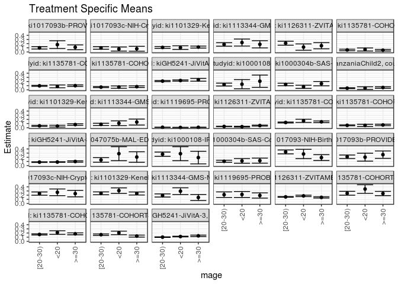

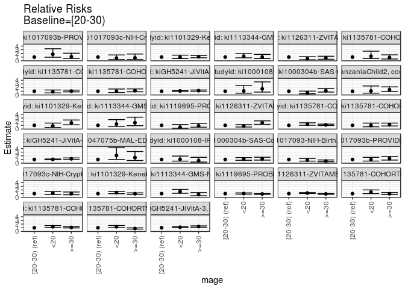

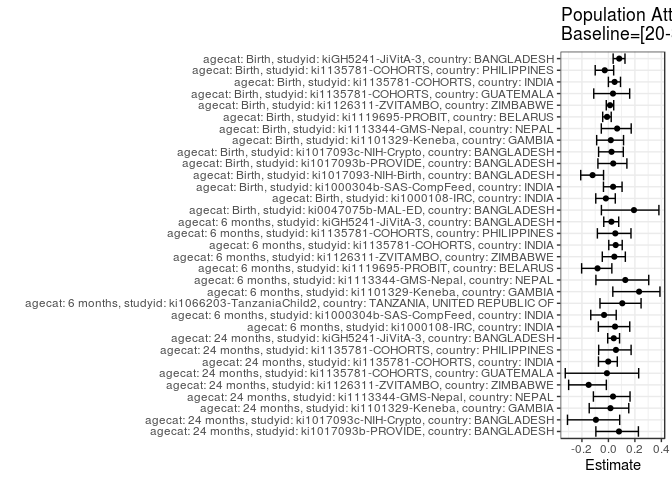

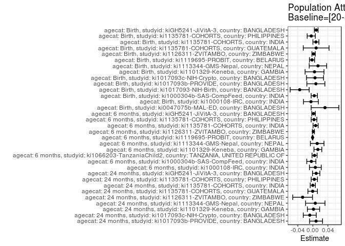

## Results Table

### Parameter: TSM

| agecat | studyid | country | intervention_level | baseline_level | estimate | ci_lower | ci_upper |
| --- | --- | --- | --- | --- | --- | --- | --- |
| Birth | ki0047075b-MAL-ED | BANGLADESH | [20-30) | NA | 0.1351351 | 0.0799289 | 0.1903413 |
| Birth | ki0047075b-MAL-ED | BANGLADESH | <20 | NA | 0.2857143 | 0.1179949 | 0.4534337 |
| Birth | ki0047075b-MAL-ED | BANGLADESH | >=30 | NA | 0.2051282 | 0.0781032 | 0.3321533 |
| Birth | ki1000108-IRC | INDIA | [20-30) | NA | 0.2733564 | 0.2218977 | 0.3248151 |
| Birth | ki1000108-IRC | INDIA | <20 | NA | 0.2857143 | 0.1181409 | 0.4532877 |
| Birth | ki1000108-IRC | INDIA | >=30 | NA | 0.1923077 | 0.0405968 | 0.3440186 |
| Birth | ki1000304b-SAS-CompFeed | INDIA | [20-30) | NA | 0.1031852 | 0.0783387 | 0.1280318 |
| Birth | ki1000304b-SAS-CompFeed | INDIA | <20 | NA | 0.1126284 | 0.0563850 | 0.1688717 |
| Birth | ki1000304b-SAS-CompFeed | INDIA | >=30 | NA | 0.1189596 | 0.0584794 | 0.1794398 |
| Birth | ki1017093-NIH-Birth | BANGLADESH | [20-30) | NA | 0.3282389 | 0.2814079 | 0.3750699 |
| Birth | ki1017093-NIH-Birth | BANGLADESH | <20 | NA | 0.2789916 | 0.1673314 | 0.3906518 |
| Birth | ki1017093-NIH-Birth | BANGLADESH | >=30 | NA | 0.1914755 | 0.1207655 | 0.2621855 |
| Birth | ki1017093b-PROVIDE | BANGLADESH | [20-30) | NA | 0.2119285 | 0.1700061 | 0.2538510 |
| Birth | ki1017093b-PROVIDE | BANGLADESH | <20 | NA | 0.2020104 | 0.1064880 | 0.2975328 |
| Birth | ki1017093b-PROVIDE | BANGLADESH | >=30 | NA | 0.2623167 | 0.1732872 | 0.3513463 |
| Birth | ki1017093c-NIH-Crypto | BANGLADESH | [20-30) | NA | 0.2375382 | 0.1990286 | 0.2760478 |
| Birth | ki1017093c-NIH-Crypto | BANGLADESH | <20 | NA | 0.2675479 | 0.1873960 | 0.3476999 |
| Birth | ki1017093c-NIH-Crypto | BANGLADESH | >=30 | NA | 0.2373761 | 0.1591143 | 0.3156380 |
| Birth | ki1101329-Keneba | GAMBIA | [20-30) | NA | 0.2438099 | 0.2101327 | 0.2774872 |
| Birth | ki1101329-Keneba | GAMBIA | <20 | NA | 0.3087095 | 0.2427443 | 0.3746747 |
| Birth | ki1101329-Keneba | GAMBIA | >=30 | NA | 0.2395594 | 0.2036253 | 0.2754934 |
| Birth | ki1113344-GMS-Nepal | NEPAL | [20-30) | NA | 0.1923289 | 0.1545764 | 0.2300815 |
| Birth | ki1113344-GMS-Nepal | NEPAL | <20 | NA | 0.2953261 | 0.2145220 | 0.3761301 |
| Birth | ki1113344-GMS-Nepal | NEPAL | >=30 | NA | 0.1437695 | 0.0716263 | 0.2159127 |
| Birth | ki1119695-PROBIT | BELARUS | [20-30) | NA | 0.2109375 | 0.1446584 | 0.2772166 |
| Birth | ki1119695-PROBIT | BELARUS | <20 | NA | 0.2156003 | 0.1442107 | 0.2869899 |
| Birth | ki1119695-PROBIT | BELARUS | >=30 | NA | 0.1913611 | 0.1281414 | 0.2545808 |
| Birth | ki1126311-ZVITAMBO | ZIMBABWE | [20-30) | NA | 0.1573277 | 0.1496125 | 0.1650430 |
| Birth | ki1126311-ZVITAMBO | ZIMBABWE | <20 | NA | 0.1820429 | 0.1646006 | 0.1994853 |
| Birth | ki1126311-ZVITAMBO | ZIMBABWE | >=30 | NA | 0.1456507 | 0.1300086 | 0.1612928 |

[output cut: 69 more lines]

### Parameter: E(Y)

| agecat | studyid | country | intervention_level | baseline_level | estimate | ci_lower | ci_upper |
| --- | --- | --- | --- | --- | --- | --- | --- |
| Birth | ki0047075b-MAL-ED | BANGLADESH | NA | NA | 0.1674419 | 0.1174176 | 0.2174661 |
| Birth | ki1000108-IRC | INDIA | NA | NA | 0.2682216 | 0.2212677 | 0.3151755 |
| Birth | ki1000304b-SAS-CompFeed | INDIA | NA | NA | 0.1069810 | 0.0760961 | 0.1378659 |
| Birth | ki1017093-NIH-Birth | BANGLADESH | NA | NA | 0.2931937 | 0.2558878 | 0.3304996 |
| Birth | ki1017093b-PROVIDE | BANGLADESH | NA | NA | 0.2199248 | 0.1846953 | 0.2551543 |
| Birth | ki1017093c-NIH-Crypto | BANGLADESH | NA | NA | 0.2432815 | 0.2116319 | 0.2749310 |
| Birth | ki1101329-Keneba | GAMBIA | NA | NA | 0.2482947 | 0.2261720 | 0.2704173 |
| Birth | ki1113344-GMS-Nepal | NEPAL | NA | NA | 0.2059282 | 0.1745993 | 0.2372572 |
| Birth | ki1119695-PROBIT | BELARUS | NA | NA | 0.2087491 | 0.1435025 | 0.2739957 |
| Birth | ki1126311-ZVITAMBO | ZIMBABWE | NA | NA | 0.1593044 | 0.1529843 | 0.1656245 |
| Birth | ki1135781-COHORTS | GUATEMALA | NA | NA | 0.2539683 | 0.2229196 | 0.2850169 |
| Birth | ki1135781-COHORTS | INDIA | NA | NA | 0.1734393 | 0.1622569 | 0.1846217 |
| Birth | ki1135781-COHORTS | PHILIPPINES | NA | NA | 0.1555709 | 0.1423748 | 0.1687670 |
| Birth | kiGH5241-JiVitA-3 | BANGLADESH | NA | NA | 0.1095191 | 0.1043958 | 0.1146423 |
| 6 months | ki1000108-IRC | INDIA | NA | NA | 0.1323529 | 0.0994307 | 0.1652752 |
| 6 months | ki1000304b-SAS-CompFeed | INDIA | NA | NA | 0.1244378 | 0.0992652 | 0.1496104 |
| 6 months | ki1066203-TanzaniaChild2 | TANZANIA, UNITED REPUBLIC OF | NA | NA | 0.0432621 | 0.0343680 | 0.0521561 |
| 6 months | ki1101329-Keneba | GAMBIA | NA | NA | 0.0576923 | 0.0476698 | 0.0677148 |
| 6 months | ki1113344-GMS-Nepal | NEPAL | NA | NA | 0.0904255 | 0.0667359 | 0.1141152 |
| 6 months | ki1119695-PROBIT | BELARUS | NA | NA | 0.0082498 | 0.0066007 | 0.0098989 |
| 6 months | ki1126311-ZVITAMBO | ZIMBABWE | NA | NA | 0.0312169 | 0.0275173 | 0.0349165 |
| 6 months | ki1135781-COHORTS | INDIA | NA | NA | 0.1321217 | 0.1226366 | 0.1416069 |
| 6 months | ki1135781-COHORTS | PHILIPPINES | NA | NA | 0.0594974 | 0.0505830 | 0.0684118 |
| 6 months | kiGH5241-JiVitA-3 | BANGLADESH | NA | NA | 0.0846892 | 0.0798858 | 0.0894926 |
| 24 months | ki1017093b-PROVIDE | BANGLADESH | NA | NA | 0.1070812 | 0.0818727 | 0.1322897 |
| 24 months | ki1017093c-NIH-Crypto | BANGLADESH | NA | NA | 0.0875486 | 0.0630907 | 0.1120065 |
| 24 months | ki1101329-Keneba | GAMBIA | NA | NA | 0.1096210 | 0.0948307 | 0.1244113 |
| 24 months | ki1113344-GMS-Nepal | NEPAL | NA | NA | 0.1868583 | 0.1522030 | 0.2215136 |
| 24 months | ki1126311-ZVITAMBO | ZIMBABWE | NA | NA | 0.1828704 | 0.1463759 | 0.2193648 |
| 24 months | ki1135781-COHORTS | GUATEMALA | NA | NA | 0.0464684 | 0.0338852 | 0.0590516 |
| 24 months | ki1135781-COHORTS | INDIA | NA | NA | 0.0957708 | 0.0862423 | 0.1052993 |
| 24 months | ki1135781-COHORTS | PHILIPPINES | NA | NA | 0.0681911 | 0.0582056 | 0.0781766 |
| 24 months | kiGH5241-JiVitA-3 | BANGLADESH | NA | NA | 0.2181903 | 0.2083363 | 0.2280442 |

### Parameter: RR

| agecat | studyid | country | intervention_level | baseline_level | estimate | ci_lower | ci_upper |
| --- | --- | --- | --- | --- | --- | --- | --- |
| Birth | ki0047075b-MAL-ED | BANGLADESH | [20-30) | [20-30) | 1.0000000 | 1.0000000 | 1.0000000 |
| Birth | ki0047075b-MAL-ED | BANGLADESH | <20 | [20-30) | 2.1142857 | 1.0341049 | 4.3227760 |
| Birth | ki0047075b-MAL-ED | BANGLADESH | >=30 | [20-30) | 1.5179487 | 0.7228866 | 3.1874546 |
| Birth | ki1000108-IRC | INDIA | [20-30) | [20-30) | 1.0000000 | 1.0000000 | 1.0000000 |
| Birth | ki1000108-IRC | INDIA | <20 | [20-30) | 1.0452080 | 0.5645305 | 1.9351651 |
| Birth | ki1000108-IRC | INDIA | >=30 | [20-30) | 0.7035054 | 0.3126330 | 1.5830697 |
| Birth | ki1000304b-SAS-CompFeed | INDIA | [20-30) | [20-30) | 1.0000000 | 1.0000000 | 1.0000000 |
| Birth | ki1000304b-SAS-CompFeed | INDIA | <20 | [20-30) | 1.0915165 | 0.7830524 | 1.5214922 |
| Birth | ki1000304b-SAS-CompFeed | INDIA | >=30 | [20-30) | 1.1528746 | 0.8224362 | 1.6160764 |
| Birth | ki1017093-NIH-Birth | BANGLADESH | [20-30) | [20-30) | 1.0000000 | 1.0000000 | 1.0000000 |
| Birth | ki1017093-NIH-Birth | BANGLADESH | <20 | [20-30) | 0.8499650 | 0.5560925 | 1.2991371 |
| Birth | ki1017093-NIH-Birth | BANGLADESH | >=30 | [20-30) | 0.5833419 | 0.3927943 | 0.8663255 |
| Birth | ki1017093b-PROVIDE | BANGLADESH | [20-30) | [20-30) | 1.0000000 | 1.0000000 | 1.0000000 |
| Birth | ki1017093b-PROVIDE | BANGLADESH | <20 | [20-30) | 0.9532006 | 0.5716475 | 1.5894260 |
| Birth | ki1017093b-PROVIDE | BANGLADESH | >=30 | [20-30) | 1.2377604 | 0.8366352 | 1.8312051 |
| Birth | ki1017093c-NIH-Crypto | BANGLADESH | [20-30) | [20-30) | 1.0000000 | 1.0000000 | 1.0000000 |
| Birth | ki1017093c-NIH-Crypto | BANGLADESH | <20 | [20-30) | 1.1263363 | 0.8015930 | 1.5826404 |
| Birth | ki1017093c-NIH-Crypto | BANGLADESH | >=30 | [20-30) | 0.9993175 | 0.6924484 | 1.4421804 |
| Birth | ki1101329-Keneba | GAMBIA | [20-30) | [20-30) | 1.0000000 | 1.0000000 | 1.0000000 |
| Birth | ki1101329-Keneba | GAMBIA | <20 | [20-30) | 1.2661893 | 0.9817978 | 1.6329589 |
| Birth | ki1101329-Keneba | GAMBIA | >=30 | [20-30) | 0.9825661 | 0.8013021 | 1.2048342 |
| Birth | ki1113344-GMS-Nepal | NEPAL | [20-30) | [20-30) | 1.0000000 | 1.0000000 | 1.0000000 |
| Birth | ki1113344-GMS-Nepal | NEPAL | <20 | [20-30) | 1.5355261 | 1.0965892 | 2.1501583 |
| Birth | ki1113344-GMS-Nepal | NEPAL | >=30 | [20-30) | 0.7475189 | 0.4359271 | 1.2818300 |
| Birth | ki1119695-PROBIT | BELARUS | [20-30) | [20-30) | 1.0000000 | 1.0000000 | 1.0000000 |
| Birth | ki1119695-PROBIT | BELARUS | <20 | [20-30) | 1.0221049 | 0.8688886 | 1.2023388 |
| Birth | ki1119695-PROBIT | BELARUS | >=30 | [20-30) | 0.9071931 | 0.7926062 | 1.0383458 |
| Birth | ki1126311-ZVITAMBO | ZIMBABWE | [20-30) | [20-30) | 1.0000000 | 1.0000000 | 1.0000000 |
| Birth | ki1126311-ZVITAMBO | ZIMBABWE | <20 | [20-30) | 1.1570938 | 1.0390485 | 1.2885500 |
| Birth | ki1126311-ZVITAMBO | ZIMBABWE | >=30 | [20-30) | 0.9257787 | 0.8227447 | 1.0417160 |

[output cut: 69 more lines]

### Parameter: PAR

| agecat | studyid | country | intervention_level | baseline_level | estimate | ci_lower | ci_upper |
| --- | --- | --- | --- | --- | --- | --- | --- |
| Birth | ki0047075b-MAL-ED | BANGLADESH | [20-30) | NA | 0.0323067 | -0.0044929 | 0.0691063 |
| Birth | ki1000108-IRC | INDIA | [20-30) | NA | -0.0051348 | -0.0248945 | 0.0146249 |
| Birth | ki1000304b-SAS-CompFeed | INDIA | [20-30) | NA | 0.0037957 | -0.0045469 | 0.0121384 |
| Birth | ki1017093-NIH-Birth | BANGLADESH | [20-30) | NA | -0.0350452 | -0.0602889 | -0.0098014 |
| Birth | ki1017093b-PROVIDE | BANGLADESH | [20-30) | NA | 0.0079963 | -0.0160282 | 0.0320207 |
| Birth | ki1017093c-NIH-Crypto | BANGLADESH | [20-30) | NA | 0.0057432 | -0.0169280 | 0.0284145 |
| Birth | ki1101329-Keneba | GAMBIA | [20-30) | NA | 0.0044848 | -0.0206613 | 0.0296308 |
| Birth | ki1113344-GMS-Nepal | NEPAL | [20-30) | NA | 0.0135993 | -0.0096287 | 0.0368273 |
| Birth | ki1119695-PROBIT | BELARUS | [20-30) | NA | -0.0021884 | -0.0089328 | 0.0045559 |
| Birth | ki1126311-ZVITAMBO | ZIMBABWE | [20-30) | NA | 0.0019767 | -0.0025033 | 0.0064567 |
| Birth | ki1135781-COHORTS | GUATEMALA | [20-30) | NA | 0.0087481 | -0.0255927 | 0.0430889 |
| Birth | ki1135781-COHORTS | INDIA | [20-30) | NA | 0.0081129 | 0.0001680 | 0.0160578 |
| Birth | ki1135781-COHORTS | PHILIPPINES | [20-30) | NA | -0.0043008 | -0.0151397 | 0.0065382 |
| Birth | kiGH5241-JiVitA-3 | BANGLADESH | [20-30) | NA | 0.0089330 | 0.0040401 | 0.0138260 |
| 6 months | ki1000108-IRC | INDIA | [20-30) | NA | 0.0066219 | -0.0090812 | 0.0223251 |
| 6 months | ki1000304b-SAS-CompFeed | INDIA | [20-30) | NA | -0.0040674 | -0.0162266 | 0.0080917 |
| 6 months | ki1066203-TanzaniaChild2 | TANZANIA, UNITED REPUBLIC OF | [20-30) | NA | 0.0045377 | -0.0022040 | 0.0112794 |
| 6 months | ki1101329-Keneba | GAMBIA | [20-30) | NA | 0.0133657 | 0.0029534 | 0.0237780 |
| 6 months | ki1113344-GMS-Nepal | NEPAL | [20-30) | NA | 0.0115367 | -0.0065748 | 0.0296483 |
| 6 months | ki1119695-PROBIT | BELARUS | [20-30) | NA | -0.0006772 | -0.0016216 | 0.0002672 |
| 6 months | ki1126311-ZVITAMBO | ZIMBABWE | [20-30) | NA | 0.0013986 | -0.0013146 | 0.0041119 |
| 6 months | ki1135781-COHORTS | INDIA | [20-30) | NA | 0.0072505 | 0.0005328 | 0.0139681 |
| 6 months | ki1135781-COHORTS | PHILIPPINES | [20-30) | NA | 0.0030990 | -0.0044408 | 0.0106387 |
| 6 months | kiGH5241-JiVitA-3 | BANGLADESH | [20-30) | NA | 0.0019403 | -0.0028393 | 0.0067200 |
| 24 months | ki1017093b-PROVIDE | BANGLADESH | [20-30) | NA | 0.0085516 | -0.0086753 | 0.0257785 |
| 24 months | ki1017093c-NIH-Crypto | BANGLADESH | [20-30) | NA | -0.0082597 | -0.0255539 | 0.0090344 |
| 24 months | ki1101329-Keneba | GAMBIA | [20-30) | NA | 0.0017196 | -0.0145873 | 0.0180266 |
| 24 months | ki1113344-GMS-Nepal | NEPAL | [20-30) | NA | 0.0065051 | -0.0192684 | 0.0322786 |
| 24 months | ki1126311-ZVITAMBO | ZIMBABWE | [20-30) | NA | -0.0272746 | -0.0535163 | -0.0010329 |
| 24 months | ki1135781-COHORTS | GUATEMALA | [20-30) | NA | -0.0005241 | -0.0132499 | 0.0122017 |
| 24 months | ki1135781-COHORTS | INDIA | [20-30) | NA | -0.0001352 | -0.0069329 | 0.0066625 |
| 24 months | ki1135781-COHORTS | PHILIPPINES | [20-30) | NA | 0.0038797 | -0.0044637 | 0.0122230 |
| 24 months | kiGH5241-JiVitA-3 | BANGLADESH | [20-30) | NA | 0.0088319 | -0.0009699 | 0.0186337 |

### Parameter: PAF

| agecat | studyid | country | intervention_level | baseline_level | estimate | ci_lower | ci_upper |
| --- | --- | --- | --- | --- | --- | --- | --- |
| Birth | ki0047075b-MAL-ED | BANGLADESH | [20-30) | NA | 0.1929429 | -0.0529073 | 0.3813880 |
| Birth | ki1000108-IRC | INDIA | [20-30) | NA | -0.0191440 | -0.0955205 | 0.0519078 |
| Birth | ki1000304b-SAS-CompFeed | INDIA | [20-30) | NA | 0.0354805 | -0.0373305 | 0.1031807 |
| Birth | ki1017093-NIH-Birth | BANGLADESH | [20-30) | NA | -0.1195291 | -0.2090447 | -0.0366411 |
| Birth | ki1017093b-PROVIDE | BANGLADESH | [20-30) | NA | 0.0363591 | -0.0792523 | 0.1395861 |
| Birth | ki1017093c-NIH-Crypto | BANGLADESH | [20-30) | NA | 0.0236074 | -0.0741529 | 0.1124703 |
| Birth | ki1101329-Keneba | GAMBIA | [20-30) | NA | 0.0180623 | -0.0886537 | 0.1143174 |
| Birth | ki1113344-GMS-Nepal | NEPAL | [20-30) | NA | 0.0660390 | -0.0536100 | 0.1721006 |
| Birth | ki1119695-PROBIT | BELARUS | [20-30) | NA | -0.0104836 | -0.0431379 | 0.0211486 |
| Birth | ki1126311-ZVITAMBO | ZIMBABWE | [20-30) | NA | 0.0124082 | -0.0161185 | 0.0401340 |
| Birth | ki1135781-COHORTS | GUATEMALA | [20-30) | NA | 0.0344458 | -0.1107201 | 0.1606391 |
| Birth | ki1135781-COHORTS | INDIA | [20-30) | NA | 0.0467768 | -0.0000993 | 0.0914557 |
| Birth | ki1135781-COHORTS | PHILIPPINES | [20-30) | NA | -0.0276451 | -0.0996953 | 0.0396845 |
| Birth | kiGH5241-JiVitA-3 | BANGLADESH | [20-30) | NA | 0.0815661 | 0.0357683 | 0.1251888 |
| 6 months | ki1000108-IRC | INDIA | [20-30) | NA | 0.0500325 | -0.0758153 | 0.1611587 |
| 6 months | ki1000304b-SAS-CompFeed | INDIA | [20-30) | NA | -0.0326865 | -0.1332902 | 0.0589866 |
| 6 months | ki1066203-TanzaniaChild2 | TANZANIA, UNITED REPUBLIC OF | [20-30) | NA | 0.1048883 | -0.0636953 | 0.2467534 |
| 6 months | ki1101329-Keneba | GAMBIA | [20-30) | NA | 0.2316721 | 0.0332956 | 0.3893400 |
| 6 months | ki1113344-GMS-Nepal | NEPAL | [20-30) | NA | 0.1275826 | -0.0944472 | 0.3045694 |
| 6 months | ki1119695-PROBIT | BELARUS | [20-30) | NA | -0.0820889 | -0.2022044 | 0.0260255 |
| 6 months | ki1126311-ZVITAMBO | ZIMBABWE | [20-30) | NA | 0.0448039 | -0.0461512 | 0.1278510 |
| 6 months | ki1135781-COHORTS | INDIA | [20-30) | NA | 0.0548772 | 0.0027502 | 0.1042794 |
| 6 months | ki1135781-COHORTS | PHILIPPINES | [20-30) | NA | 0.0520857 | -0.0832630 | 0.1705232 |
| 6 months | kiGH5241-JiVitA-3 | BANGLADESH | [20-30) | NA | 0.0229114 | -0.0351767 | 0.0777399 |
| 24 months | ki1017093b-PROVIDE | BANGLADESH | [20-30) | NA | 0.0798607 | -0.0946759 | 0.2265690 |
| 24 months | ki1017093c-NIH-Crypto | BANGLADESH | [20-30) | NA | -0.0943446 | -0.3091652 | 0.0852260 |
| 24 months | ki1101329-Keneba | GAMBIA | [20-30) | NA | 0.0156872 | -0.1449077 | 0.1537556 |
| 24 months | ki1113344-GMS-Nepal | NEPAL | [20-30) | NA | 0.0348130 | -0.1133633 | 0.1632687 |
| 24 months | ki1126311-ZVITAMBO | ZIMBABWE | [20-30) | NA | -0.1491469 | -0.3002840 | -0.0155771 |
| 24 months | ki1135781-COHORTS | GUATEMALA | [20-30) | NA | -0.0112782 | -0.3257854 | 0.2286206 |
| 24 months | ki1135781-COHORTS | INDIA | [20-30) | NA | -0.0014115 | -0.0749658 | 0.0671098 |
| 24 months | ki1135781-COHORTS | PHILIPPINES | [20-30) | NA | 0.0568938 | -0.0734804 | 0.1714341 |
| 24 months | kiGH5241-JiVitA-3 | BANGLADESH | [20-30) | NA | 0.0404778 | -0.0053502 | 0.0842168 |